# Survival analysis Raji model

Leander Meuris

2026-04-08

Purpose of the experiment is to look at the effect of MGAT5 engineering in CART-cells in a mouse tumor model. The model uses Raji cells, which create blood tumors of the Burkitt’s lymphoma type. These cells are CD19, CD20 and CD70 positive.

The experiments have appr. the following timelines:

- day -1 or -2: weight baseline measurement
- day 0: injection of Raji cells IV
- day 4, 5 or 6: start of weight and IVIS measurements
- day: 7 CART cell injection
- around day 130: rechallenge if applicable

Careful; depending on the data source file, the days can be relative to injection of Raji cells, but also relative to the start of the CART cell engineering, which starts typically 6 days earlier. That means that the day of Raji injection would become day 6 and CART cell injection day 13.

The mice are followed up via body weight measurements and IVIS data, which measures luminescence of the Raji cells in the mice. There are several experiments:

Experiment 51:

- PBS: no cells given
- NTC: 4 million cells donor T-cells, no CAR T cells
- CD70 CART WT 4 million cells
- CD70 CART MGAT5 4 million cells
- CD70 CART WT 2 million cells
- CD70 CART MGAT5 2 million cells
- CD20 CART WT 1 million cells
- CD20 CART MGAT5 1 million cells
- CD20 CART WT 0.5 million cells
- CD20 CART MGAT5 0.5 million cells

Experiment 62 and 68:

- NTC: 4 million cells donor T-cells, no CAR T cells
- CD70 CART WT 4 million cells
- CD70 CART MGAT5 4 million cells
- CD20 CART WT 0.5 million cells
- CD20 CART MGAT5 0.5 million cells
- CD19 CART WT 2 million cells
- CD19 CART MGAT5 2 million cells

- NTC: 4 million cells donor T-cells, no CAR T cells
- CD70 CART WT 4 million cells
- CD70 CART MGAT5 4 million cells
- CD20 CART WT 0.5 million cells
- CD20 CART MGAT5 0.5 million cells

Experiment 91, 97 and 103:

- NTC
- CD19 CART WT
- CD19 CART MGAT5

Summarizing we can say that:

There was a rechallenge part to experiments 51 and 74 but not to 62, 68, 91 and 97. Exp 103 is still running. A rechallenge means that tumor cells were administered again after a set period. We also note the end-day of the experiments, as we need this for calculations of the survival times.

Note: for Exp 91, the IVIS machine was unavailable, so it was terminated prematurely. Note 2: in the analyses below, the CD20 data is not used. The metadata thus only contains info on the mice that are used.

```r
# These are days since tumor inoculation
day_rechallenge_E51 <- 133
day_rechallenge_E62 <- NA
day_rechallenge_E68 <- NA
day_rechallenge_E74 <- 139
day_rechallenge_E91 <- NA
day_rechallenge_E97 <- NA #26/3/26: in fact, there was a rechallenge, but ignored it since too little mice for plots and stats
day_rechallenge_E103 <- NA #26/3/26: exp still running, rechallenge may or may not happen

day_end_E51 <- 216
day_end_E62 <- 83
day_end_E68 <- 88
day_end_E74 <- 202
day_end_E91 <- 25
day_end_E97 <- 137 #26/3/26: did not end on day 137, but decided to use this as end date, since too few mice for rechallenge.
day_end_E103 <- 63 #26/3/26: exp still running, end date not final
```

The question we want to answer are:

Is the MGAT5 effect tumor model independent? I.e. do we see an MGAT5 effect in these experiments like we saw in the SKOV3 tumor model?

In this particular script, we will focus on the survival analysis.

# Data

First, we load all the data

```r
sheets <- excel_sheets(here('data/data_cleaned.xlsx'))
datalist <- map(sheets, read_xlsx, path = here('data/data_cleaned.xlsx'))
names(datalist) <- sheets
```

## Metadata & Survival data

Get the metadata

```r
metadata <- datalist$Metadata
Survival <- datalist$Survival
Survival <- left_join(Survival, metadata)
```

In the survival data;

- Event1: event during primary challenge
  - 0 = mouse did not experience an event or was censored (e.g. due to bleeding for ex-vivo cell culture)
  - 1 = mouse died of tumor
  - 2 = mouse died of other cause (unknown, GVHD, …)
- Event2: event during rechallenge, only for mice that survived primary challenge.
  - 0 = mouse did not experience an event or was censored (e.g. due to bleeding for ex-vivo cell culture)
  - 1 = mouse died of tumor
  - 2 = mouse died of other cause (unknown, GVHD, …)

## Weight data

```r
Weight <- datalist[str_detect(names(datalist), 'Weight')] %>% # select only weight data
  map(~ pivot_longer(.x,
                     cols = -Day_SinceTumorInoculation,
                     names_to = 'Mouse',
                     values_to= 'Weight')) %>%
  bind_rows(.id = 'Experiment') %>%
  mutate(Experiment = str_remove(Experiment, 'Weight'),
         Mouse = as.numeric(Mouse),
         Day = Day_SinceTumorInoculation) %>%
  filter(!is.na(Weight)) %>%
  select(Experiment, Mouse, Day, Weight) %>%
  arrange(Experiment, Mouse, Day)

Weight <- left_join(Weight, Survival) %>%
  mutate(GVHD = ifelse(is.na(GVHD), 'No or unknown', GVHD),
         Event1 = factor(Event1,
                        labels = c('Survived or censored',
                                   'Died of tumor',
                                   'Died of other cause')),
         Event2 = factor(Event2,
                        labels = c('Survived or censored',
                                   'Died of tumor',
                                   'Died of other cause')))
```

Clean up

```r
rm(metadata, datalist, sheets)
```

# Data cleaning

Parse variables to correct type Remove some data that are superfluous or problematic:

EXP51: - Mouse 21 in exp 51 was a sentinel mouse

EXP62: - Mouse 26 and 27 in exp 62 were spare, were not used - Mouse 18, 23, 24, 25, 28 in exp 62 died from heat of the lamps so cannot be used in analysis

EXP68: - Mice 1, 22 were not in the experiment and 38-43 were backup in exp 68.

EXP74: - Mouse 22: euthanized due to unsure Raji injection - Mouse 30: euthanized by accident - Mouse 29: excluded due to unsure Raji injection - Mouse 46 and 47: controls for Raji effectiveness at secondary injection

```r
Weight <- Weight %>%
  filter(!(Mouse %in% c(18,23,24,25,26,27,28) & Experiment == 'E62')) %>%
  filter(!(Mouse == 21 & Experiment == 'E51')) %>%
  filter(!(Mouse %in% c(1,22,38,39,40,41,42,43) & Experiment == 'E68')) %>%
  filter(!(Mouse %in% c(22,29,30,46,47) & Experiment == 'E74')) %>%
  filter(!is.na(Treatment)) %>%
  filter(Dose %in% c(0,4) | is.na(Dose)) %>%
  arrange(Experiment, Mouse, Day) %>%
  mutate(Experiment = factor(Experiment, levels = c('E51', 'E62', 'E68', 'E74',
                                                    'E91', 'E97', 'E103')),
         ID = fct_inorder(paste0(Experiment, 'M', Mouse)),
         Treatment = factor(Treatment),
         Target = factor(Target, levels =c('Ctrl', 'CD70', 'CD19')),
         MGAT5 = factor(MGAT5, levels = c('Ctrl', 'MGAT5WT', 'MGAT5KO')),
         Day_Rechallenge = case_when(
           Experiment == 'E51' ~ day_rechallenge_E51,
           Experiment == 'E62' ~ day_rechallenge_E62,
           Experiment == 'E68' ~ day_rechallenge_E68,
           Experiment == 'E74' ~ day_rechallenge_E74,
           Experiment == 'E91' ~ day_rechallenge_E91,
           Experiment == 'E97' ~ day_rechallenge_E97,
           Experiment == 'E103' ~ day_rechallenge_E103),
         Day_End = case_when(
           Experiment == 'E51' ~ day_end_E51,
           Experiment == 'E62' ~ day_end_E62,
           Experiment == 'E68' ~ day_end_E68,
           Experiment == 'E74' ~ day_end_E74,
           Experiment == 'E91' ~ day_end_E91,
           Experiment == 'E97' ~ day_end_E97,
           Experiment == 'E103' ~ day_end_E103),
         Day_SinceTumorInoculation = Day,
         Day_SinceTCellIsolation = Day + 6) %>%
  select(Experiment, Mouse, ID, everything())

Survival <- Survival %>%
  filter(!(Mouse %in% c(18,23,24,25,26,27,28) & Experiment == 'E62')) %>%
  filter(!(Mouse == 21 & Experiment == 'E51')) %>%
  filter(!(Mouse %in% c(1,22,38,39,40,41,42,43) & Experiment == 'E68')) %>%
  filter(!(Mouse %in% c(22,29,30,46,47) & Experiment == 'E74')) %>%
  filter(!is.na(Treatment)) %>%
  filter(Dose %in% c(0,4) | is.na(Dose)) %>%
  arrange(Experiment, Mouse) %>%
  mutate(Experiment = factor(Experiment, levels = c('E51', 'E62', 'E68', 'E74',
                                                    'E91', 'E97', 'E103')),
         ID = fct_inorder(paste0(Experiment, 'M', Mouse)),
         Treatment = factor(Treatment),
         Target = factor(Target, levels =c('Ctrl', 'CD70', 'CD19')),
         MGAT5 = factor(MGAT5, levels = c('Ctrl', 'MGAT5WT', 'MGAT5KO'))) %>%
  select(Experiment, Mouse, ID, everything())
```

Get follow up times for the survival analysis. These can be obtained from the Weight dataframe. We have follow up times for: - the primary challenge: the latest day there was an observation before the day of rechallenge, or the day of rechallenge itself. In the latter case, we have a censored observation. This is Time_FU_1. - the secondary challenge (rechallenge): the latest day there was an observation before the end of the experiment or the end of the experiment. In the latter case, we have a censored observation. This is Time_FU_2

```r
FUtimes_1 <- Weight %>%
  group_by(Experiment, ID) %>%
  filter(Day == max(Day)) %>%
  mutate(Time_FU_1 = pmin(Day, Day_Rechallenge, Day_End, na.rm = TRUE)) %>%
  select(Experiment, ID, Time_FU_1)

FUtimes_2 <- Weight %>%
  group_by(Experiment, ID) %>%
  filter(Day == max(Day)) %>%
  mutate(Time_FU_2 = pmin(Day, Day_End, na.rm = TRUE)) %>%
  select(Experiment, ID, Time_FU_2)

Survival <- left_join(Survival, FUtimes_1)
Survival <- left_join(Survival, FUtimes_2)
rm(Weight, FUtimes_1, FUtimes_2)
```

Write datasheets to xlsx files for later reference

```r
#Survival %>% writexl::write_xlsx(here('output/Survival.xlsx'))
```

Some data QC

```r
#Survival %>% map(~any(is.na(.)))
#Survival %>%
#  filter(Experiment %in% c('E51', 'E74')) %>%
#  filter(is.na(Event2))
```

# Survival tables and plots

## Primary tumor, per experiment

We check how many mice died of the tumor in each treatment setting. First, we filter out all mice for which the cause of death was not the tumor during the first challenge. I.e. event type = 2.

```r
tableall_70 <- Survival %>%
  filter(Event1 != 2) %>%
  filter(Experiment %in% c('E51', 'E62','E68', 'E74')) %>%
  filter(Target %in% c('CD70', 'Ctrl')) %>%
  group_by(Experiment, Target, Dose, MGAT5, Treatment) %>%
  summarise(Total = n(),
            Cases = sum(Event1 == 1)) %>%
  mutate(`%` = signif(Cases/Total, 3)*100,
         Case_Tot_pct = paste0(`%`, '%', ' (', Cases, '/', Total, ')')) %>%
  select(-c(Cases, Total, `%`)) %>%
  arrange(Experiment, Target, Dose, MGAT5, Treatment)

tableall_70 %>% writexl::write_xlsx(here("output/SurvivalTable_CD70_Raji_Primary.xlsx"))
tableall_70
```

```
## # A tibble: 13 × 6
## # Groups:   Experiment, Target, Dose, MGAT5 [13]
##    Experiment Target  Dose MGAT5   Treatment                   Case_Tot_pct
##    <fct>      <fct>  <dbl> <fct>   <fct>                       <chr>
##  1 E51        Ctrl       0 Ctrl    PBS                         100% (5/5)
##  2 E51        Ctrl       4 Ctrl    NTC                         100% (5/5)
##  3 E51        CD70       4 MGAT5WT CD70 nanoCAR-WT - 4 000 000 100% (5/5)
##  4 E51        CD70       4 MGAT5KO CD70 nanoCAR-KO - 4 000 000 100% (5/5)
##  5 E62        Ctrl       4 Ctrl    NTC                         100% (4/4)
##  6 E62        CD70       4 MGAT5WT CD70 nanoCAR-WT - 4 000 000 25% (1/4)
##  7 E62        CD70       4 MGAT5KO CD70 nanoCAR-KO - 4 000 000 0% (0/4)
##  8 E68        Ctrl       4 Ctrl    NTC                         100% (5/5)
##  9 E68        CD70       4 MGAT5WT CD70 nanoCAR-WT - 4 000 000 80% (4/5)
## 10 E68        CD70       4 MGAT5KO CD70 nanoCAR-KO - 4 000 000 0% (0/4)
## 11 E74        Ctrl       4 Ctrl    NTC                         100% (7/7)
## 12 E74        CD70       4 MGAT5WT CD70 nanoCAR-WT - 4 000 000 87.5% (7/8)
## 13 E74        CD70       4 MGAT5KO CD70 nanoCAR-KO - 4 000 000 33.3% (2/6)
```

```r
tableall_19 <- Survival %>%
  filter(Event1 != 2) %>%
  filter(Experiment %in% c('E91', 'E97', 'E103')) %>%
  filter(Target %in% c('CD19', 'Ctrl')) %>%
  group_by(Experiment, Target, MGAT5, Treatment) %>%
  summarise(Total = n(),
            Cases = sum(Event1 == 1, na.rm = TRUE)) %>%
  mutate(`%` = signif(Cases/Total, 3)*100,
         Case_Tot_pct = paste0(`%`, '%', ' (', Cases, '/', Total, ')')) %>%
  select(-c(Cases, Total, `%`)) %>%
  arrange(Experiment, Target, MGAT5, Treatment)

tableall_19 %>% writexl::write_xlsx(here("output/SurvivalTable_CD19_Raji_Primary.xlsx"))
tableall_19
```

```
## # A tibble: 9 × 5
## # Groups:   Experiment, Target, MGAT5 [9]
##   Experiment Target MGAT5   Treatment           Case_Tot_pct
##   <fct>      <fct>  <fct>   <fct>               <chr>
## 1 E91        Ctrl   Ctrl    NTC                 75% (6/8)
## 2 E91        CD19   MGAT5WT CD19 CAR - mock     0% (0/8)
## 3 E91        CD19   MGAT5KO CD19 CAR - MGAT5 KO 0% (0/8)
## 4 E97        Ctrl   Ctrl    NTC                 100% (6/6)
## 5 E97        CD19   MGAT5WT CD19 CAR - mock     91.7% (11/12)
## 6 E97        CD19   MGAT5KO CD19 CAR - MGAT5 KO 36.4% (4/11)
## 7 E103       Ctrl   Ctrl    NTC                 70% (7/10)
## 8 E103       CD19   MGAT5WT CD19 CAR - mock     52.9% (9/17)
## 9 E103       CD19   MGAT5KO CD19 CAR - MGAT5 KO 43.8% (7/16)
```

# Survival analysis only primary and per donor

We will do the survival analysis per target. A certain dose was used as the ‘standard’ dose, and this is repeated in each experiment: - control (NTC): 4 million cells, all experiments - CD70: 4 million cells, all exps

We collect the data for each analysis in a separate dataframe. We also remove all mice that died from other causes (e.g. GVHD)

```r
Survival <- Survival %>%
  mutate(Event = Event1,
         Time_FU = Time_FU_1,
         cMGAT5 = as.character(MGAT5))

CD70 <- Survival %>%
  filter((Target == 'CD70' & Dose == '4') |
           (Target == 'Ctrl' & Experiment %in% c('E51', 'E62','E68', 'E74') & Dose == '4')) %>%
  filter(Event %in% c('0', '1'))

surv_CD70 <- Surv(CD70$Time_FU, CD70$Event)

CD19 <- Survival %>%
  filter((Target == 'CD19') |
           (Target == 'Ctrl' & Experiment %in% c('E91', 'E97', 'E103'))) %>%
  filter(Event %in% c('0', '1'))

surv_CD19 <- Surv(CD19$Time_FU, CD19$Event)

simple_palette = c(
    rgb(44,20,83, maxColorValue = 255),
    rgb(14,111,124, maxColorValue = 255),
    rgb(251,79,6, maxColorValue = 255)

    )
stratify_palette = c(
    rgb(44,20,83, maxColorValue = 255),
    rgb(251,79,6, maxColorValue = 255),
    rgb(14,111,124, maxColorValue = 255)
    )

?Surv
```

```
## Help on topic 'Surv' was found in the following packages:
##
##   Package               Library
##   ggsurvfit             /Library/Frameworks/R.framework/Versions/4.5-arm64/Resources/library
##   survival              /Library/Frameworks/R.framework/Versions/4.5-arm64/Resources/library
##
##
## Using the first match ...
```

## CD70

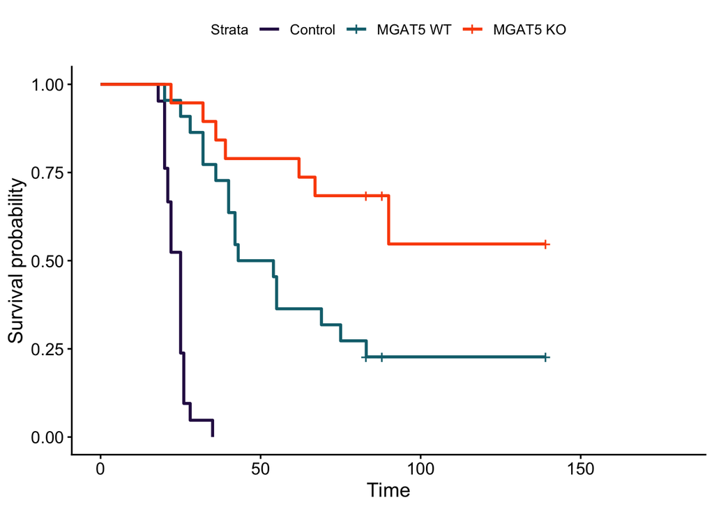

```r
sCD70 <- survfit2(surv_CD70 ~ MGAT5, data = CD70)
CD70_combi <- ggsurvplot(sCD70, data = CD70, palette = simple_palette,
                         legend.labs = c('Control', 'MGAT5 WT', 'MGAT5 KO'),
                         xlim = c(0,180))
CD70_perexp <- ggsurvplot_facet(sCD70, facet.by = 'Experiment', data = CD70,
                                palette = stratify_palette,
                                xlim = c(0,180))

CD70_combi$plot <- CD70_combi$plot

CD70_perexp <- CD70_perexp

ggsave(here('output/SurvivalPlot_CD70_Raji_allExp_primary.pdf'), CD70_combi$plot,
       device = 'pdf', width  = 8, height = 5)

ggsave(here('output/SurvivalPlot_CD70_Raji_perExp_primary.pdf'), CD70_perexp,
       device = 'pdf', width = 8, height = 5)

CD70_combi
```

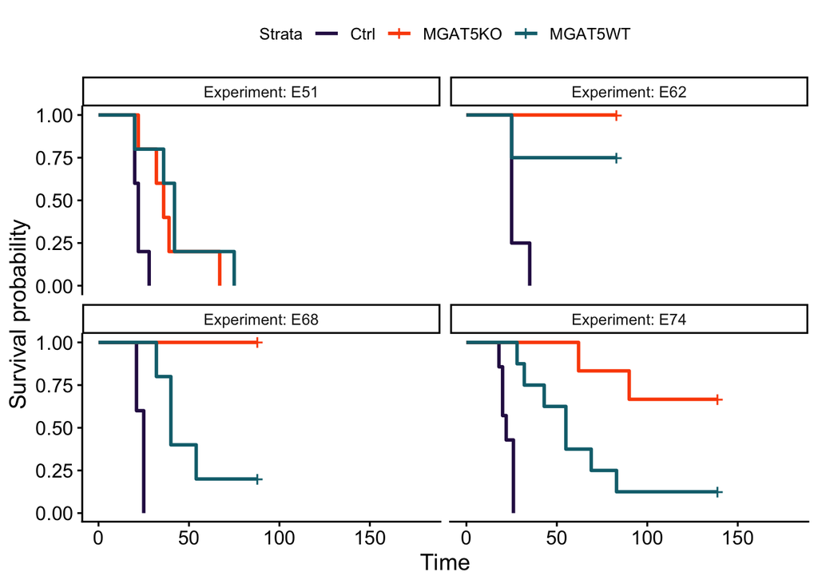

```r
CD70_perexp
```

```r
CD70 %>%
  filter(MGAT5 != 'Ctrl') %>%
  group_by(Experiment) %>%
  summarise(pval = survdiff(Surv(Time_FU_1, Event1) ~ MGAT5)$pval %>% round(.,3)) %>%
  mutate(Model = 'Raji, anti-CD70, Survival for primary tumor') %>%
  select(Model, everything())
```

```
## # A tibble: 4 × 3
##   Model                                       Experiment  pval
##   <chr>                                       <fct>      <dbl>
## 1 Raji, anti-CD70, Survival for primary tumor E51        0.388
## 2 Raji, anti-CD70, Survival for primary tumor E62        0.317
## 3 Raji, anti-CD70, Survival for primary tumor E68        0.026
## 4 Raji, anti-CD70, Survival for primary tumor E74        0.019
```

## CD19

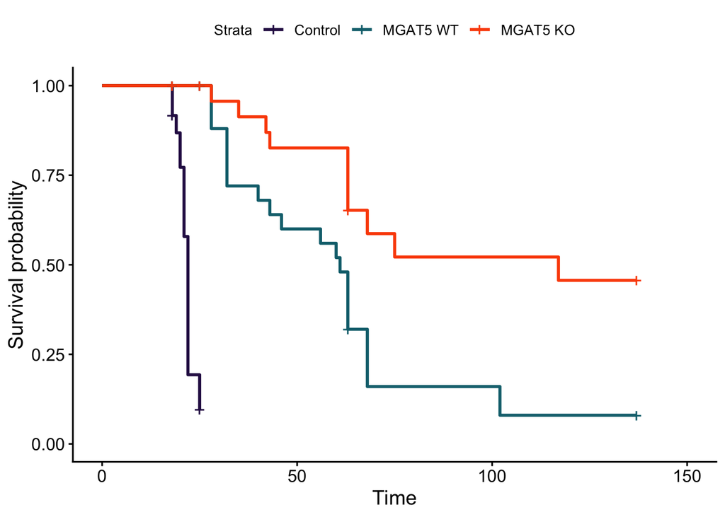

```r
sCD19 <- survfit2(surv_CD19 ~ MGAT5, data = CD19)
CD19_combi <- ggsurvplot(sCD19, data = CD19, palette = simple_palette,
                         legend.labs = c('Control', 'MGAT5 WT', 'MGAT5 KO'),
                         xlim = c(0,150))
CD19_perexp <- ggsurvplot_facet(sCD19, facet.by = 'Experiment', data = CD19,
                                palette = stratify_palette,
                                xlim = c(0,150))

CD19_combi$plot <- CD19_combi$plot

CD19_perexp <- CD19_perexp

ggsave(here('output/SurvivalPlot_CD19_Raji_allExp_primary.pdf'), CD19_combi$plot,
       device = 'pdf', width  = 8, height = 5)

ggsave(here('output/SurvivalPlot_CD19_Raji_perExp_primary.pdf'), CD19_perexp,
       device = 'pdf', width = 8, height = 5)

CD19_combi
```

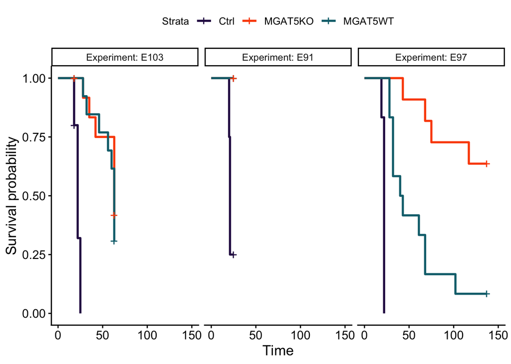

```r
CD19_perexp
```

```r
CD19 %>%
  filter(MGAT5 != 'Ctrl') %>%
  group_by(Experiment) %>%
  summarise(pval = survdiff(Surv(Time_FU_1, Event1) ~ MGAT5)$pval %>% round(.,3)) %>%
  mutate(Model = 'Raji, anti-CD19, Survival for primary tumor') %>%
  select(Model, everything())
```

```
## # A tibble: 3 × 3
##   Model                                       Experiment    pval
##   <chr>                                       <fct>        <dbl>
## 1 Raji, anti-CD19, Survival for primary tumor E91        NaN
## 2 Raji, anti-CD19, Survival for primary tumor E97          0.001
## 3 Raji, anti-CD19, Survival for primary tumor E103         0.542
```

```r
citation()
```

```
##
##   R Core Team (2025). _R: A Language and Environment for Statistical
##   Computing_. R Foundation for Statistical Computing, Vienna, Austria.
##   <https://www.R-project.org/>.
##
## A BibTeX entry for LaTeX users is
##
##   @Manual{,
##     title = {R: A Language and Environment for Statistical Computing},
##     author = {{R Core Team}},
##     organization = {R Foundation for Statistical Computing},
##     address = {Vienna, Austria},
##     year = {2025},
##     url = {https://www.R-project.org/},
##   }
##
## We have invested a lot of time and effort in creating R, please cite it
## when using it for data analysis. See also 'citation("pkgname")' for
## citing R packages.
```